# Unidad 1: Fundamentos del lenguaje R y entorno de trabajo

Material de consulta del taller introductorio

Autor

Daniel Auliz-Ortiz

Fecha

octubre 2026

# 1 Cómo usar este documento

Este es el material de consulta de la **Unidad 1** del curso de R (X Congreso Mexicano de Ecología / I Congreso ReLatE, Puebla 2026). Reúne, ya explicado y con sus resultados, todo lo que vemos durante el taller introductorio. Está pensado para consultarlo después de la clase, junto con:

- las **diapositivas** de la unidad, y
- el **script** `introduccion_01.R`, donde escribes y corres el código durante el taller.

Al terminar esta unidad podrás:

1. Moverte en RStudio y organizar tu trabajo en un script.
2. Crear y nombrar objetos, y usar operadores y funciones básicas.
3. Instalar y cargar paquetes.
4. Distinguir los tipos de datos y convertir de uno a otro.
5. Crear y explorar vectores, matrices, arrays, data frames, tibbles y listas, y extraer partes de ellos (indexación).
6. Escribir tus propias funciones.

## 1.1 Cómo está organizado

Las secciones siguen el mismo orden del script:

| Este documento | Script `introduccion_01.R` |
| --- | --- |
| 2. ¿Qué es R? | (sólo diapositivas) |
| 3. RStudio y primeros pasos | 0 |
| 4. Las bases de R | 1 |
| 5. Paquetes | 2 |
| 6. Tipos de datos | 3 |
| 7. Tipos de objetos | 4 |
| 8. Funciones | 5 |
| 9. Cierre | 6 |

## 1.2 Convenciones

- Los bloques de código se pueden copiar con el botón de la esquina superior derecha.
- Lo que aparece justo debajo de cada bloque, con `#>` al inicio, es el resultado que devuelve R.
- Los cuadros de colores marcan notas, consejos y advertencias.
- Los **ejercicios** aparecen en una franja morada. Intenta resolverlos primero: la **solución** está en un cuadro plegable justo debajo.

**NotaSi quieres correr el código tú mismo**

La mayoría de los ejemplos de este documento están en el script `introduccion_01.R` (descárgalo con clic derecho > *Guardar enlace como…*). Ábrelo en RStudio y corre cada línea con `Ctrl + Enter`. Los ejercicios los resuelves ahí mismo, en el espacio en blanco que sigue a cada uno.

## 1.3 Qué necesitas

- **R** y **RStudio** instalados.
- Los paquetes `tidyverse`, `readxl` y `lubridate` (la instalación se explica en la Sección 5).

# 2 ¿Qué es R?

R es un **lenguaje de programación** y un entorno de desarrollo diseñado específicamente para estadística y análisis de datos.

Ventajas de R:

- Es de **código abierto y gratuito**.
- Tiene una **gran comunidad** de usuarios y desarrolladores.
- Cuenta con **abundantes paquetes** y herramientas específicas para ecología y otras disciplinas.

## 2.1 ¿Qué cosas puedes hacer?

Con R puedes hacer gráficos, mapas, análisis estadísticos, modelos y reportes como este mismo documento. Como adelanto, estas pocas líneas producen una gráfica con los datos de ejemplo `iris` que vienen incluidos en R. (Los paquetes los explicamos en la Sección 5.)

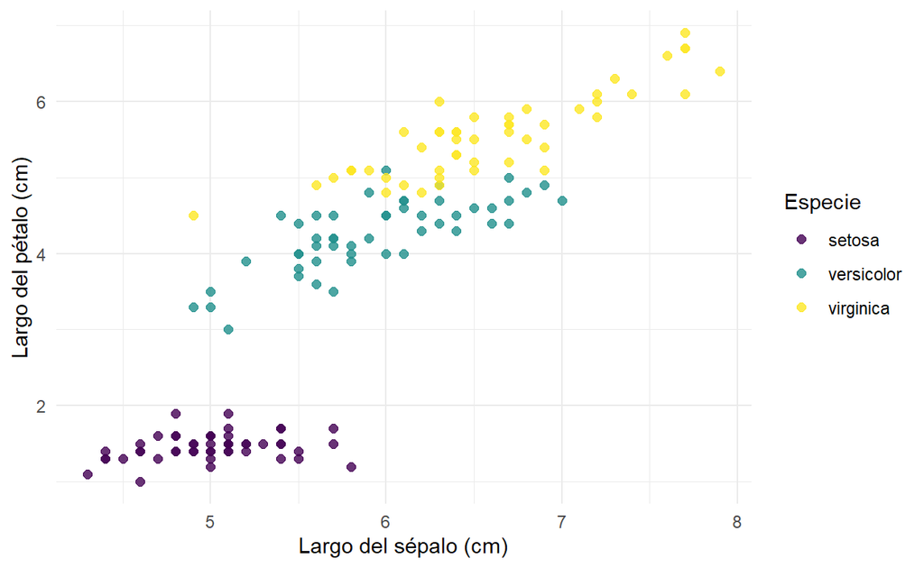

Figura 1: Gráfica hecha con ggplot2 con los datos de ejemplo iris.

```r
library(ggplot2)

ggplot(iris, aes(x = Sepal.Length, y = Petal.Length, color = Species)) +
  geom_point(size = 2, alpha = 0.8) +
  scale_color_viridis_d() +
  theme_minimal() +
  labs(x = "Largo del sépalo (cm)", y = "Largo del pétalo (cm)", color = "Especie")
```

## 2.2 Antes de R

Antes de R existía **S**, un lenguaje diseñado para análisis estadísticos. Sentó las bases de la sintaxis que después R retoma y mejora. S era un software privado, usado en algunos sectores, pero su uso no se extendió.

## 2.3 Línea de tiempo

| Año | Hito |
| --- | --- |
| **1976** | Se crea S |
| **1993** | Comienza la programación de R |
| **1995** | Primer lanzamiento público de R |
| **1997** | Formación del R Core Team |
| **2000** | Versión 1.0 de R |
| **2003** | Consolidación de CRAN |
| **2007** | Sale ggplot (hoy ggplot2) |
| **2011** | Lanzamiento de RStudio |
| **2017** | Se consolida el tidyverse |
| **2025** | R sigue siendo uno de los lenguajes más populares en ciencia |

R fue creado por **Ross Ihaka y Robert Gentleman**, de la Universidad de Auckland (Nueva Zelanda), quienes describieron el lenguaje en Ihaka y Gentleman (1996).

## 2.4 R y RStudio

Es común confundirlos, pero son cosas distintas:

| Característica | R | RStudio |
| --- | --- | --- |
| ¿Qué es? | Lenguaje de programación | Entorno de desarrollo integrado |
| Función | Calcula, grafica, hace modelos | Facilita la organización, edición y graficación de código |
| Interfaz | Consola simple | Dividida en 4 partes con funciones distintas |
| Gráficos | En ventanas externas | Los muestra directamente |
| Síntesis | Es el motor que hace el código | Es la interfaz para interactuar |

**ConsejoUna analogía**

R es el motor de un coche; RStudio es el tablero, el volante y los pedales. Puedes usar el motor sin el tablero, pero conducir es mucho más cómodo con él.

# 3 RStudio y primeros pasos

## 3.1 Las partes de RStudio

RStudio se divide en cuatro paneles:

**Editor de scripts** Aquí escribes y guardas tu código para usarlo después.

**Entorno global** Muestra los objetos que existen en tu sesión de trabajo.

**Consola** Aquí R ejecuta el código y muestra los resultados, sin guardarlos necesariamente.

**Utilidades** Ayuda, gráficas, paquetes, archivos y visor (Help, Plots, Packages, Files, Viewer).

**NotaScript o consola**

Escribe tu código en el **script**, no directamente en la consola: el script se guarda y se puede volver a correr; lo que escribes en la consola se pierde.

## 3.2 Atajos de teclado útiles

| Acción | Windows / Linux | Mac |
| --- | --- | --- |
| Ejecutar línea o selección | `Ctrl + Enter` | `Cmd + Enter` |
| Ejecutar todo el script | `Ctrl + Alt + R` | `Cmd + Option + R` |
| Asignación `<-` | `Alt + -` | `Option + -` |
| Pipe `%>%` | `Ctrl + Shift + M` | `Cmd + Shift + M` |
| Comentar / descomentar | `Ctrl + Shift + C` | `Cmd + Shift + C` |
| Limpiar la consola | `Ctrl + L` | `Ctrl + L` |
| Reiniciar R | `Ctrl + Shift + F10` | `Cmd + Shift + F10` |
| Índice del script | `Ctrl + Shift + O` | `Cmd + Shift + O` |
| Autocompletar | `Tab` | `Tab` |
| Recuperar código anterior (en la consola) | `↑` | `↑` |

## 3.3 Primeros pasos

```r
1 + 1                      # R funciona como una calculadora
```

```
#> [1] 2
```

```r
"Hola, R"                  # el texto va entre comillas
```

```
#> [1] "Hola, R"
```

```r
print("Hola, R")           # imprime en la consola
```

```
#> [1] "Hola, R"
```

Todo lo que sigue a un `#` es un **comentario**: R lo ignora. Úsalos para explicarle a tu “yo del futuro” qué hace cada línea y por qué.

## 3.4 Pedir ayuda

```r
?mean                      # abre la ayuda de una función
help("sd")                 # es lo mismo
```

Fuera de R, copia el mensaje de error completo en un buscador: casi siempre alguien ya tuvo la misma duda.

# 4 Las bases de R

R es un lenguaje **orientado a objetos**, aunque está profundamente influenciado por la programación **funcional**. En la práctica significa dos cosas:

- Las unidades con que trabaja se llaman **objetos** (un número, una tabla, un modelo…).
- Los objetos se transforman a través de **funciones**.

## 4.1 R como calculadora

```r
20 + 35                    # suma
```

```
#> [1] 55
```

```r
100 - 25                   # resta
```

```
#> [1] 75
```

```r
25 * 4                     # multiplicación
```

```
#> [1] 100
```

```r
625 / 5                    # división
```

```
#> [1] 125
```

```r
5 ^ 2                      # potencia
```

```
#> [1] 25
```

```r
sqrt(144)                  # raíz cuadrada
```

```
#> [1] 12
```

```r
log(10)                    # logaritmo natural
```

```
#> [1] 2.302585
```

```r
log(10, base = 10)         # logaritmo base 10
```

```
#> [1] 1
```

```r
exp(2.302585)              # exponente: es la inversa de log()
```

```
#> [1] 9.999999
```

También existen el residuo y la división entera, y los paréntesis cambian el orden de las operaciones:

```r
10 %% 3                    # residuo
```

```
#> [1] 1
```

```r
10 %/% 3                   # división entera
```

```
#> [1] 3
```

```r
2 + 3 * 4                  # primero la multiplicación
```

```
#> [1] 14
```

```r
(2 + 3) * 4                # los paréntesis cambian el orden
```

```
#> [1] 20
```

## 4.2 Operadores lógicos

Comparan valores y devuelven `TRUE` o `FALSE`.

| Operador | Descripción | Ejemplo | Resultado |
| --- | --- | --- | --- |
| `==` | Igual a | `5 == 5` | `TRUE` |
| `!=` | No es igual a | `5 != 3` | `TRUE` |
| `>` | Mayor que | `5 > 3` | `TRUE` |
| `<` | Menor que | `5 < 3` | `FALSE` |
| `>=` | Mayor o igual a | `5 >= 5` | `TRUE` |
| `<=` | Menor o igual a | `3 <= 5` | `TRUE` |
| `&` | Y lógico (AND) | `(5 > 3) & (2 < 4)` | `TRUE` |
| `\|` | O lógico (OR) | `(2 > 3) \| (5 > 3)` | `TRUE` |
| `!` | Negación lógica (NOT) | `!(5 > 3)` | `FALSE` |

```r
5 == 5
```

```
#> [1] TRUE
```

```r
5 != 3
```

```
#> [1] TRUE
```

```r
(5 > 3) & (2 < 4)
```

```
#> [1] TRUE
```

```r
(2 > 3) | (5 > 3)
```

```
#> [1] TRUE
```

```r
!(5 > 3)
```

```
#> [1] FALSE
```

Los operadores también trabajan con varios valores a la vez:

```r
c(1, 5, 10) > 4
```

```
#> [1] FALSE  TRUE  TRUE
```

**AdvertenciaOjo: `=` no es `==`**

Un solo `=` **asigna** un valor; dos `==` **comparan**. Confundirlos es uno de los errores más comunes al empezar.

## 4.3 Objetos y asignación

Un **objeto** es un “contenedor” con nombre. Para crear uno se usa el operador de asignación `<-` (atajo: `Alt + -`):

```r
a <- 1
b = 2                      # = también funciona, pero en R se prefiere <-

a
```

```
#> [1] 1
```

```r
b
```

```
#> [1] 2
```

```r
a + b
```

```
#> [1] 3
```

R intenta identificar todo lo que escribes:

| Cómo lo escribes | R lo interpreta como | Ejemplos |
| --- | --- | --- |
| Sin comillas ni paréntesis | Un **objeto** | `a`, `b`, `resultado` |
| Con paréntesis | Una **función** | `mean()`, `sum()` |
| Entre comillas | **Texto** | `"Lunes"` |
| Sólo dígitos | Un **número** | `23` |

Si le asignas otro valor a un objeto que ya existe, el valor anterior se pierde:

```r
nombre <- "Juan"
x <- 5
x <- 10                    # al reasignar, el valor anterior se pierde
x
```

```
#> [1] 10
```

## 4.4 Cómo nombrar objetos

Las reglas:

- Pueden tener letras, números, `_` y `.`
- No pueden empezar con un número ni llevar espacios.
- R **distingue mayúsculas de minúsculas**: `x` y `X` son objetos distintos.
- Evita nombres de funciones que ya existen (`mean`, `sum`, `c`, `t`, `df`, `data`).
- Usa nombres cortos pero que digan qué contienen: `abundancia`, `temp_media`.

**Ejercicio B1. ¿Cuáles funcionan y cuáles no?** Para cada línea: (1) predice qué pasará, (2) córrela, (3) lee el mensaje de R y explica por qué funciona o por qué falla.

```r
x == 5
nombre <- Juan
mean <- 10
2datos <- 14
salario juan <- 1500
X
Hola mundo
resultado * 2
3 -> j
(j + resultado) * x
```

**ConsejoSolución B1**

En este documento `x` vale 10.

| Línea | ¿Qué pasa? | ¿Por qué? |
| --- | --- | --- |
| `x == 5` | Funciona: devuelve `FALSE` | `==` **compara**, no asigna. Para asignar se usa `<-`. |
| `nombre <- Juan` | Error: `objeto 'Juan' no encontrado` | Sin comillas R busca un objeto llamado Juan. El texto va entre comillas: `"Juan"`. |
| `mean <- 10` | Funciona, pero es mala idea | Crea un objeto llamado igual que la función `mean()`. Evita nombres de funciones. Se borra con `rm(mean)`. |
| `2datos <- 14` | Error: `unexpected symbol` | Un nombre no puede empezar con un número. |
| `salario juan <- 1500` | Error: `unexpected symbol` | Los nombres no llevan espacios. Usa `salario_juan`. |
| `X` | Error: `objeto 'X' no encontrado` | R distingue mayúsculas: existe `x`, no `X`. |
| `Hola mundo` | Error: `unexpected symbol` | El texto necesita comillas: `"Hola mundo"`. |
| `resultado * 2` | Error: `objeto 'resultado' no encontrado` | `resultado` todavía no existe: hay que crearlo antes. |
| `3 -> j` | Funciona | `->` asigna hacia la derecha: es lo mismo que `j <- 3`. |
| `(j + resultado) * x` | Funciona sólo si `j`, `resultado` y `x` existen | Aquí falla porque `resultado` no existe. |

Una vez que creamos `resultado`, las líneas que fallaban por esa causa funcionan:

```r
resultado <- 4
resultado * 2
```

```
#> [1] 8
```

```r
3 -> j
(j + resultado) * x
```

```
#> [1] 70
```

## 4.5 Funciones estadísticas básicas

Para que los resultados sean **reproducibles** fijamos una semilla antes de generar números aleatorios. Así todas las personas obtienen los mismos números.

```r
set.seed(2026)
aleatorio <- runif(20, min = 10, max = 30)    # 20 números entre 10 y 30
aleatorio
```

```
#>  [1] 23.97347 21.13061 12.80280 15.71447 21.10738 10.50262 19.32461 27.22021
#>  [9] 15.05002 21.61613 10.11867 23.83732 14.62250 26.97065 13.07670 17.13619
#> [17] 20.90409 10.02395 16.35649 10.34579
```

```r
sum(aleatorio)             # suma
```

```
#> [1] 351.8347
```

```r
mean(aleatorio)            # promedio
```

```
#> [1] 17.59173
```

```r
median(aleatorio)          # mediana
```

```
#> [1] 16.74634
```

```r
sd(aleatorio)              # desviación estándar
```

```
#> [1] 5.596945
```

```r
min(aleatorio)             # mínimo
```

```
#> [1] 10.02395
```

```r
max(aleatorio)             # máximo
```

```
#> [1] 27.22021
```

```r
length(aleatorio)          # longitud: cuántos datos hay
```

```
#> [1] 20
```

```r
round(aleatorio, 1)        # redondear a 1 decimal
```

```
#>  [1] 24.0 21.1 12.8 15.7 21.1 10.5 19.3 27.2 15.1 21.6 10.1 23.8 14.6 27.0 13.1
#> [16] 17.1 20.9 10.0 16.4 10.3
```

**Nota**

El promedio teórico de números entre 10 y 30 es 20, pero con sólo 20 datos el promedio observado varía. Con más datos, se acerca más a 20.

`print()` imprime un objeto en la consola. En la práctica, basta con escribir el nombre del objeto:

```r
print(aleatorio[1:5])
```

```
#> [1] 23.97347 21.13061 12.80280 15.71447 21.10738
```

```r
aleatorio[1:5]
```

```
#> [1] 23.97347 21.13061 12.80280 15.71447 21.10738
```

## 4.6 Trabajando con texto

`paste()` y `paste0()` pegan texto. La diferencia es el separador: `paste0()` no usa ninguno.

```r
paste0("Hugo", "Paco", "Luis")              # sin separación
```

```
#> [1] "HugoPacoLuis"
```

```r
paste("Hugo", "Paco", "Luis")               # separados por un espacio
```

```
#> [1] "Hugo Paco Luis"
```

```r
paste("Hugo", "Paco", "Luis", sep = "_")    # con el separador que elijas
```

```
#> [1] "Hugo_Paco_Luis"
```

```r
paste("Sitio", 1:3)                         # trabaja con varios valores a la vez
```

```
#> [1] "Sitio 1" "Sitio 2" "Sitio 3"
```

## 4.7 Revisar y borrar objetos

```r
ls()                       # lista de los objetos que existen en la sesión
```

```
#> [1] "a"         "aleatorio" "b"         "j"         "nombre"    "resultado"
#> [7] "x"
```

```r
rm(aleatorio)              # borra un objeto
ls()
```

```
#> [1] "a"         "b"         "j"         "nombre"    "resultado" "x"
```

```r
rm(list = ls())            # borra todos los objetos de la sesión
ls()
```

```
#> character(0)
```

**AdvertenciaCuidado con `rm(list = ls())`**

Borra **todo** lo que tienes en memoria y no hay “deshacer”. Otra forma de empezar desde cero es reiniciar la sesión: *Session > Restart R* (`Ctrl + Shift + F10`).

# 5 Paquetes

Los **paquetes** son conjuntos de funciones, datos y código adicionales a R que permiten extender su potencial. Los desarrollan los propios usuarios, cada uno con funciones específicas para aplicaciones específicas, y se almacenan en repositorios como **CRAN** (The Comprehensive R Archive Network) o **GitHub**.

## 5.1 Instalar y cargar

Usar un paquete requiere dos pasos:

1. **Instalarlo**, una sola vez por computadora (necesita internet).
2. **Cargarlo**, en cada sesión nueva.

```r
install.packages("tidyverse")
install.packages("readxl")
install.packages("lubridate")
install.packages("ggplot2")        # ya viene dentro de tidyverse
```

```r
library(tidyverse)
library(readxl)
library(lubridate)
```

**ConsejoUna analogía**

Instalar un paquete es como comprar un libro y ponerlo en tu estante (se hace una vez). Cargarlo con `library()` es sacarlo del estante y abrirlo (se hace cada vez que vas a usarlo).

Al cargar el tidyverse, R avisa de los **conflictos**: funciones con el mismo nombre en dos paquetes. R usa la del paquete que cargaste **al último**.

## 5.2 Funciones con el mismo nombre en distintos paquetes

`select()` existe en `dplyr` (selecciona columnas) y en `MASS` (selecciona el modelo óptimo). Para evitar ambigüedad se escribe `paquete::función()`:

```r
dplyr::select(iris, Species) %>% head()
```

```
#>   Species
#> 1  setosa
#> 2  setosa
#> 3  setosa
#> 4  setosa
#> 5  setosa
#> 6  setosa
```

Veamos qué pasa si cargamos MASS:

```r
library(MASS)              # avisa que select() ahora es la de MASS
```

```r
try(select(iris, Species)) # falla: ahora select() es la de MASS
```

```
#> Error in select(iris, Species) : unused argument (Species)
```

```r
dplyr::select(iris, Species) %>% head()     # con :: siempre funciona
```

```
#>   Species
#> 1  setosa
#> 2  setosa
#> 3  setosa
#> 4  setosa
#> 5  setosa
#> 6  setosa
```

Si ya no necesitas MASS, puedes descargarlo y `select()` vuelve a ser la de dplyr:

```r
detach("package:MASS", unload = TRUE)
select(iris, Species) %>% head()
```

```
#>   Species
#> 1  setosa
#> 2  setosa
#> 3  setosa
#> 4  setosa
#> 5  setosa
#> 6  setosa
```

**Consejo**

Si dudas de qué paquete viene una función, escribe `paquete::función()`.

## 5.3 El tidyverse

El **tidyverse** es un conjunto de paquetes de R diseñados para trabajar de forma coherente en el análisis de datos. Todos comparten:

- **Una filosofía común:** datos ordenados (*tidy data*), código legible y reproducible.
- **Sintaxis consistente:** funciones con nombres predecibles y estructura similar.
- **Interoperabilidad:** los paquetes están pensados para usarse juntos, evitando conflictos.

```r
tidyverse_packages()
```

```
#>  [1] "broom"         "conflicted"    "cli"           "dbplyr"
#>  [5] "dplyr"         "dtplyr"        "forcats"       "ggplot2"
#>  [9] "googledrive"   "googlesheets4" "haven"         "hms"
#> [13] "httr"          "jsonlite"      "lubridate"     "magrittr"
#> [17] "modelr"        "pillar"        "purrr"         "ragg"
#> [21] "readr"         "readxl"        "reprex"        "rlang"
#> [25] "rstudioapi"    "rvest"         "stringr"       "tibble"
#> [29] "tidyr"         "xml2"          "tidyverse"
```

## 5.4 Un adelanto: el pipe

El **pipe** (`%>%`, o `|>` en R base) pasa lo que está a su izquierda como primer argumento de la función de su derecha. `x %>% f()` equivale a `f(x)` y se lee “x, y luego f”. Atajo: `Ctrl + Shift + M`.

```r
sqrt(144)
```

```
#> [1] 12
```

```r
144 %>% sqrt()
```

```
#> [1] 12
```

Lo usaremos en algunos ejemplos; en la siguiente unidad lo veremos a fondo.

## 5.5 ¿Dónde aprender más sobre un paquete?

- **Cheatsheets** (hojas de referencia rápida): *Help > Cheat Sheets* en RStudio, o https://posit.co/resources/cheatsheets/.
- **Manuales y viñetas** de cada paquete, por ejemplo `help(package = "dplyr")`.

# 6 Tipos de datos

Cada valor en R tiene un tipo. Los cinco más comunes:

| Tipo | Se muestra como | Ejemplo | Descripción |
| --- | --- | --- | --- |
| Numérico | `num` / `dbl` | `a <- 5.5` | Números decimales |
| Entero | `int` | `j <- 10L` | Números enteros (se escriben con `L`) |
| Lógico | `logi` | `p <- TRUE` | Valores booleanos: `TRUE` / `FALSE` |
| Carácter | `chr` | `z <- "Manzana"` | Texto o cadena de letras |
| Factor | `factor` | `t <- factor("Azul")` | Datos categóricos con niveles finitos |

```r
a <- 5.5                   # numérico
j <- 10L                   # entero
p <- TRUE                  # lógico
z <- "Manzana"             # carácter
t <- factor("Azul")        # factor

class(a)
```

```
#> [1] "numeric"
```

```r
class(j)
```

```
#> [1] "integer"
```

```r
class(p)
```

```
#> [1] "logical"
```

```r
class(z)
```

```
#> [1] "character"
```

```r
class(t)
```

```
#> [1] "factor"
```

## 6.1 Verificar y convertir

`class()` dice de qué tipo es un objeto. Las funciones `is.*()` preguntan “¿es de este tipo?” y las `as.*()` convierten a otro tipo.

| Tipo | Verificar | Convertir |
| --- | --- | --- |
| Numérico | `is.numeric()` | `as.numeric()` |
| Entero | `is.integer()` | `as.integer()` |
| Lógico | `is.logical()` | `as.logical()` |
| Carácter | `is.character()` | `as.character()` |
| Factor | `is.factor()` | `as.factor()` |

```r
h <- 18.5
is.numeric(h)
```

```
#> [1] TRUE
```

```r
class(h)
```

```
#> [1] "numeric"
```

```r
d <- 20
is.numeric(d)
```

```
#> [1] TRUE
```

```r
class(d)                   # R guarda los números como decimales
```

```
#> [1] "numeric"
```

```r
d <- as.integer(d)         # convertimos
class(d)
```

```
#> [1] "integer"
```

## 6.2 Lo que pasa al convertir

No toda conversión tiene sentido, y algunas tienen sorpresas:

```r
as.numeric(t)              # el factor es un código, no un texto
```

```
#> [1] 1
```

```r
as.factor(12)
```

```
#> [1] 12
#> Levels: 12
```

```r
as.logical(t)              # no todo se puede convertir
```

```
#> [1] NA
```

```r
as.numeric(FALSE)          # FALSE vale 0 (y TRUE vale 1)
```

```
#> [1] 0
```

```r
as.integer(3.9)            # corta, NO redondea
```

```
#> [1] 3
```

```r
as.numeric("hola")         # no es un número: da NA y una advertencia
```

```
#> Warning: NAs introducidos por coerción
#> [1] NA
```

**AdvertenciaUn error clásico: números guardados como factor**

Si una columna de números se importa como factor, `as.numeric()` **no** devuelve los valores, sino los códigos internos de los niveles. Para recuperar los valores, pasa primero por carácter:

```r
f <- factor(c("10", "20", "10", "30"))
as.numeric(f)                  # ¡códigos internos, no los valores!
```

```
#> [1] 1 2 1 3
```

```r
as.numeric(as.character(f))    # así sí
```

```
#> [1] 10 20 10 30
```

```r
levels(f)                      # los niveles del factor
```

```
#> [1] "10" "20" "30"
```

```r
nlevels(f)                     # cuántos niveles hay
```

```
#> [1] 3
```

**Ejercicio T1.** Designa una variable `p` que valga 7. Verifica a qué tipo de variable corresponde (¿cuál crees que será?). Por último, conviértela a número entero.

**ConsejoSolución T1**

```r
p <- 7
class(p)
```

```
#> [1] "numeric"
```

```r
p <- as.integer(p)
class(p)
```

```
#> [1] "integer"
```

**Ejercicio T2.** Designa una variable `f` que contenga la palabra viernes. Verifica el tipo de variable que crees que sea. Conviértela a factor.

**ConsejoSolución T2**

```r
f <- "viernes"
class(f)
```

```
#> [1] "character"
```

```r
f <- as.factor(f)
class(f)
```

```
#> [1] "factor"
```

**Ejercicio T3.** Designa una variable `k` que valga 15.6. Verifica a qué tipo corresponde. Por último, conviértela a carácter.

**ConsejoSolución T3**

```r
k <- 15.6
class(k)
```

```
#> [1] "numeric"
```

```r
k <- as.character(k)
k
```

```
#> [1] "15.6"
```

```r
class(k)
```

```
#> [1] "character"
```

**Ejercicio T4.** Designa una variable `w` que contenga el factor llamado lluvias. Verifica el tipo de variable usando `class()`. Convierte el valor a numérico.

**ConsejoSolución T4**

```r
w <- factor("lluvias")
class(w)
```

```
#> [1] "factor"
```

```r
as.numeric(w)
```

```
#> [1] 1
```

El resultado es `1`: el código del primer (y único) nivel, no un valor real.

**Ejercicio T5.** Designa una variable `rr` que tenga como valor Verdadero (`TRUE`). Verifica el tipo de variable con `class()`. Por último, conviértela a numérico.

**ConsejoSolución T5**

```r
rr <- TRUE
class(rr)
```

```
#> [1] "logical"
```

```r
as.numeric(rr)
```

```
#> [1] 1
```

**Ejercicio T6.** Designa una variable `hh` que contenga el valor `12L`. Verifica el tipo de variable usando `class()`. Convierte el valor a factor y observa cuántos niveles tiene.

**ConsejoSolución T6**

```r
hh <- 12L
class(hh)
```

```
#> [1] "integer"
```

```r
hh <- as.factor(hh)
class(hh)
```

```
#> [1] "factor"
```

```r
nlevels(hh)
```

```
#> [1] 1
```

```r
levels(hh)
```

```
#> [1] "12"
```

## 6.3 Fechas (opcional)

Las fechas tienen su propio tipo: `Date`. El paquete `lubridate` facilita trabajar con ellas.

```r
fecha <- as.Date("2024-01-09")             # formato año-mes-día
class(fecha)
```

```
#> [1] "Date"
```

```r
fecha + 30                                 # se pueden hacer cuentas con fechas
```

```
#> [1] "2024-02-08"
```

```r
year(fecha)                                # lubridate: extraer partes
```

```
#> [1] 2024
```

```r
month(fecha)
```

```
#> [1] 1
```

```r
dmy("9/1/2024")                            # lubridate: leer otros formatos
```

```
#> [1] "2024-01-09"
```

# 7 Tipos de objetos

R trabaja con varios tipos de objetos: **vectores, matrices, arrays, data frames y listas**. Además hay objetos propios de ciertos paquetes: modelos, gráficos, objetos espaciales (raster), funciones…

Esta tabla resume las diferencias:

| Objeto | Dimensiones | ¿Mezcla tipos? | Se crea con | Se indexa con |
| --- | --- | --- | --- | --- |
| Vector | 1 | No | `c()` | `x[i]` |
| Matriz | 2 | No | `matrix()` | `m[i, j]` |
| Array | 2 o más | No | `array()` | `a[i, j, k]` |
| Data frame | 2 | Sí (un tipo por columna) | `data.frame()` | `df[i, j]`, `df$columna` |
| Tibble | 2 | Sí (un tipo por columna) | `tibble()` | igual que un data frame |
| Lista | 1 (de elementos) | Sí | `list()` | `l$nombre`, `l[["nombre"]]` |

## 7.1 Vectores

Un **vector** es una colección ordenada de elementos del **mismo tipo**, organizados en una sola dimensión. Se crean con `c()` (de “combinar”).

```r
mi_vector <- c(1, 2, 3, 4, 5)
nombres <- c("Juan", "Ana", "Pedro")
numeros <- c(1, 2, 3, 4, 5, 6, 7, 8, 9, 10)
valores_verdad <- c(TRUE, FALSE, TRUE, TRUE)
dias <- c("lunes", "martes", "miércoles", "jueves", "viernes", "sábado",
          "domingo")

class(mi_vector)
```

```
#> [1] "numeric"
```

```r
length(numeros)
```

```
#> [1] 10
```

Hay atajos para crear secuencias y repeticiones:

```r
1:10                       # secuencia de enteros
```

```
#>  [1]  1  2  3  4  5  6  7  8  9 10
```

```r
seq(0, 100, by = 25)       # secuencia con un paso
```

```
#> [1]   0  25  50  75 100
```

```r
rep("A", 3)                # repetir
```

```
#> [1] "A" "A" "A"
```

Como un vector sólo puede tener un tipo, si mezclas tipos R convierte todo al más general (**coerción**):

```r
mezcla <- c(1, "a", TRUE)
mezcla
```

```
#> [1] "1"    "a"    "TRUE"
```

```r
class(mezcla)
```

```
#> [1] "character"
```

Los vectores se pueden operar completos, sin escribir ciclos:

```r
numeros * 2
```

```
#>  [1]  2  4  6  8 10 12 14 16 18 20
```

```r
numeros + numeros
```

```
#>  [1]  2  4  6  8 10 12 14 16 18 20
```

```r
numeros > 5
```

```
#>  [1] FALSE FALSE FALSE FALSE FALSE  TRUE  TRUE  TRUE  TRUE  TRUE
```

### 7.1.1 Indexación

**Indexar** es acceder, extraer o modificar elementos específicos dentro de un objeto usando su **posición**, su **nombre** o una **condición lógica**.

```r
x <- c(10, 20, 30)

x[2]                       # por posición
```

```
#> [1] 20
```

```r
x[c(1, 3)]                 # varias posiciones
```

```
#> [1] 10 30
```

```r
x[2:3]                     # un rango
```

```
#> [1] 20 30
```

```r
x[-1]                      # todo MENOS la posición 1
```

```
#> [1] 20 30
```

Con una condición lógica:

```r
x > 15                     # primero se evalúa la condición...
```

```
#> [1] FALSE  TRUE  TRUE
```

```r
x[x > 15]                  # ...y los TRUE se quedan
```

```
#> [1] 20 30
```

```r
which(x > 15)              # ¿en qué posiciones se cumple?
```

```
#> [1] 2 3
```

```r
sum(x > 15)                # ¿cuántos la cumplen?
```

```
#> [1] 2
```

Para modificar un elemento, se asigna sobre su posición:

```r
x[2] <- 25
x
```

```
#> [1] 10 25 30
```

Y los vectores pueden tener nombres:

```r
edades <- c(Juan = 30, Ana = 25, Pedro = 41)
edades["Ana"]
```

```
#> Ana
#>  25
```

**Ejercicio V1.** Esta es la abundancia de una especie en 8 sitios:

```r
abundancia <- c(12, 0, 5, 33, 8, 1, 0, 19)
```

1. ¿Cuántos sitios hay?
2. ¿Cuál es la abundancia total?
3. ¿Cuál es la abundancia del sitio 4?

**ConsejoSolución V1**

```r
length(abundancia)         # a) número de sitios
```

```
#> [1] 8
```

```r
sum(abundancia)            # b) abundancia total
```

```
#> [1] 78
```

```r
abundancia[4]              # c) abundancia del sitio 4
```

```
#> [1] 33
```

**Ejercicio V2.**

1. Devuelve las abundancias que son mayores o iguales a 10.
2. ¿En qué sitios (posiciones) ocurre eso?
3. ¿En cuántos sitios la especie está ausente (abundancia = 0)?

**ConsejoSolución V2**

```r
abundancia[abundancia >= 10]     # a) los valores
```

```
#> [1] 12 33 19
```

```r
which(abundancia >= 10)          # b) las posiciones
```

```
#> [1] 1 4 8
```

```r
sum(abundancia == 0)             # c) cuántos ceros hay
```

```
#> [1] 2
```

## 7.2 Matrices

Una **matriz** es una estructura de datos bidimensional que almacena elementos del **mismo tipo** en filas y columnas. Es una colección rectangular de datos organizada en una cuadrícula. Se crea con `matrix()` y se indexa con `[fila, columna]`.

```r
mi_mat_01 <- matrix(c(1:20), ncol = 4, nrow = 5)
mi_mat_01
```

```
#>      [,1] [,2] [,3] [,4]
#> [1,]    1    6   11   16
#> [2,]    2    7   12   17
#> [3,]    3    8   13   18
#> [4,]    4    9   14   19
#> [5,]    5   10   15   20
```

```r
dim(mi_mat_01)             # filas, columnas
```

```
#> [1] 5 4
```

Esta tabla muestra cada valor y, entre corchetes, su posición `[fila, columna]`:

|  | col 1 | col 2 | col 3 | col 4 |
| --- | --- | --- | --- | --- |
| fila 1 | **1** [1,1] | **6** [1,2] | **11** [1,3] | **16** [1,4] |
| fila 2 | **2** [2,1] | **7** [2,2] | **12** [2,3] | **17** [2,4] |
| fila 3 | **3** [3,1] | **8** [3,2] | **13** [3,3] | **18** [3,4] |
| fila 4 | **4** [4,1] | **9** [4,2] | **14** [4,3] | **19** [4,4] |
| fila 5 | **5** [5,1] | **10** [5,2] | **15** [5,3] | **20** [5,4] |

**NotaR llena las matrices por columnas**

Por defecto, `matrix()` acomoda los valores columna por columna. Con `byrow = TRUE` los acomoda por filas:

```r
matrix(1:6, nrow = 2, byrow = TRUE)
```

```
#>      [,1] [,2] [,3]
#> [1,]    1    2    3
#> [2,]    4    5    6
```

Otra matriz, ahora de texto:

```r
nombres_matriz <- matrix(c("Juan", "Ana", "Pedro", "Elena", "Jose", "Miguel",
                           "Maria", "Adriana", "Eder", "Ines", "Joel",
                           "Patricia"),
                         nrow = 4, ncol = 3)
nombres_matriz
```

```
#>      [,1]    [,2]      [,3]
#> [1,] "Juan"  "Jose"    "Eder"
#> [2,] "Ana"   "Miguel"  "Ines"
#> [3,] "Pedro" "Maria"   "Joel"
#> [4,] "Elena" "Adriana" "Patricia"
```

### 7.2.1 Indexación de matrices

```r
mi_mat_01[3, 2]           # fila 3, columna 2
```

```
#> [1] 8
```

```r
mi_mat_01[2, ]            # toda la fila 2     (columna vacía = todas)
```

```
#> [1]  2  7 12 17
```

```r
mi_mat_01[, 2]            # toda la columna 2  (fila vacía = todas)
```

```
#> [1]  6  7  8  9 10
```

**Ejercicios M1 a M7.**

- M1. Devuelve el valor 14 de `mi_mat_01`.
- M2. Devuelve el valor 2 de `mi_mat_01`.
- M3. Devuelve sólo la fila 4 de `mi_mat_01`.
- M4. Devuelve la columna 1 de `mi_mat_01`.
- M5. Devuelve el nombre Adriana de `nombres_matriz`.
- M6. Devuelve el nombre Ines de `nombres_matriz`.
- M7. Devuelve la fila 4 de `nombres_matriz`.

**ConsejoSolución M1 a M7**

Apóyate en la tabla de posiciones de arriba.

```r
mi_mat_01[4, 3]            # M1
```

```
#> [1] 14
```

```r
mi_mat_01[2, 1]            # M2
```

```
#> [1] 2
```

```r
mi_mat_01[4, ]             # M3
```

```
#> [1]  4  9 14 19
```

```r
mi_mat_01[, 1]             # M4
```

```
#> [1] 1 2 3 4 5
```

```r
nombres_matriz[4, 2]       # M5
```

```
#> [1] "Adriana"
```

```r
nombres_matriz[2, 3]       # M6
```

```
#> [1] "Ines"
```

```r
nombres_matriz[4, ]        # M7
```

```
#> [1] "Elena"    "Adriana"  "Patricia"
```

## 7.3 Arrays

Un **array** es una estructura de datos **multidimensional** que almacena elementos del mismo tipo. Es la extensión natural de las matrices para representar datos con una organización más compleja. Se indexa con `[fila, columna, nivel]`.

```r
mi_array <- array(c(1:18), dim = c(3, 3, 2))
mi_array
```

```
#> , , 1
#>
#>      [,1] [,2] [,3]
#> [1,]    1    4    7
#> [2,]    2    5    8
#> [3,]    3    6    9
#>
#> , , 2
#>
#>      [,1] [,2] [,3]
#> [1,]   10   13   16
#> [2,]   11   14   17
#> [3,]   12   15   18
```

```r
dim(mi_array)
```

```
#> [1] 3 3 2
```

Un array de 3 × 3 × 2 es como dos matrices de 3 × 3 apiladas. Cada celda con su posición `[fila, columna, nivel]`:

**Nivel 1**

|  | col 1 | col 2 | col 3 |
| --- | --- | --- | --- |
| fila 1 | **1** [1,1,1] | **4** [1,2,1] | **7** [1,3,1] |
| fila 2 | **2** [2,1,1] | **5** [2,2,1] | **8** [2,3,1] |
| fila 3 | **3** [3,1,1] | **6** [3,2,1] | **9** [3,3,1] |

**Nivel 2**

|  | col 1 | col 2 | col 3 |
| --- | --- | --- | --- |
| fila 1 | **10** [1,1,2] | **13** [1,2,2] | **16** [1,3,2] |
| fila 2 | **11** [2,1,2] | **14** [2,2,2] | **17** [2,3,2] |
| fila 3 | **12** [3,1,2] | **15** [3,2,2] | **18** [3,3,2] |

```r
mi_array[1, 2, 2]          # fila 1, columna 2, nivel 2
```

```
#> [1] 13
```

**Ejercicios A1 a A3.**

- A1. Devuelve el valor 17 de `mi_array`.
- A2. Devuelve el valor 3 de `mi_array`.
- A3. Devuelve los valores 13, 14 y 15 al mismo tiempo de `mi_array`.

**ConsejoSolución A1 a A3**

```r
mi_array[2, 3, 2]          # A1
```

```
#> [1] 17
```

```r
mi_array[3, 1, 1]          # A2
```

```
#> [1] 3
```

```r
mi_array[, 2, 2]           # A3
```

```
#> [1] 13 14 15
```

## 7.4 Data frames

Un **data frame** es una estructura de datos bidimensional que organiza los datos en filas (observaciones) y columnas (variables), parecida a una hoja de cálculo o a una tabla de una base de datos. Su característica distintiva es que **cada columna puede tener un tipo de dato distinto**. Es el formato más común para datos ecológicos.

```r
df <- data.frame(
  no     = c(1, 2, 3, 4, 8),
  site   = c("A", "B", "A", "C", "D"),
  temp   = c(22.5, 24.5, 27, 35, 26),
  precip = c(650, 820, 698, 715, 905)
)
df
```

```
#>   no site temp precip
#> 1  1    A 22.5    650
#> 2  2    B 24.5    820
#> 3  3    A 27.0    698
#> 4  4    C 35.0    715
#> 5  8    D 26.0    905
```

### 7.4.1 Explorar un data frame

| Función | Qué devuelve |
| --- | --- |
| `class(df)` | El tipo de objeto |
| `names(df)` | Los nombres de las columnas |
| `dim(df)` | Las dimensiones (filas, columnas) |
| `nrow(df)`, `ncol(df)` | El número de filas y de columnas |
| `str(df)` | Un desglose de la estructura de los datos |
| `glimpse(df)` | Lo mismo que `str()`, en versión tidyverse |
| `head(df)` | Las primeras filas (útil cuando la tabla es grande) |
| `summary(df)` | Un resumen de cada variable |
| `df$temp` | Una columna |
| `unique(df$site)` | Los valores únicos de una columna |
| `table(df$site)` | La frecuencia de cada valor único |

```r
class(df)
```

```
#> [1] "data.frame"
```

```r
names(df)
```

```
#> [1] "no"     "site"   "temp"   "precip"
```

```r
dim(df)
```

```
#> [1] 5 4
```

```r
nrow(df)
```

```
#> [1] 5
```

```r
ncol(df)
```

```
#> [1] 4
```

```r
str(df)
```

```
#> 'data.frame':    5 obs. of  4 variables:
#>  $ no    : num  1 2 3 4 8
#>  $ site  : chr  "A" "B" "A" "C" ...
#>  $ temp  : num  22.5 24.5 27 35 26
#>  $ precip: num  650 820 698 715 905
```

```r
glimpse(df)
```

```
#> Rows: 5
#> Columns: 4
#> $ no     <dbl> 1, 2, 3, 4, 8
#> $ site   <chr> "A", "B", "A", "C", "D"
#> $ temp   <dbl> 22.5, 24.5, 27.0, 35.0, 26.0
#> $ precip <dbl> 650, 820, 698, 715, 905
```

```r
head(df)
```

```
#>   no site temp precip
#> 1  1    A 22.5    650
#> 2  2    B 24.5    820
#> 3  3    A 27.0    698
#> 4  4    C 35.0    715
#> 5  8    D 26.0    905
```

```r
summary(df)
```

```
#>        no          site                temp          precip
#>  Min.   :1.0   Length:5           Min.   :22.5   Min.   :650.0
#>  1st Qu.:2.0   Class :character   1st Qu.:24.5   1st Qu.:698.0
#>  Median :3.0   Mode  :character   Median :26.0   Median :715.0
#>  Mean   :3.6                      Mean   :27.0   Mean   :757.6
#>  3rd Qu.:4.0                      3rd Qu.:27.0   3rd Qu.:820.0
#>  Max.   :8.0                      Max.   :35.0   Max.   :905.0
```

```r
df$temp                    # una columna con $
```

```
#> [1] 22.5 24.5 27.0 35.0 26.0
```

```r
unique(df$site)            # valores únicos
```

```
#> [1] "A" "B" "C" "D"
```

```r
table(df$site)             # frecuencia de cada valor único
```

```
#>
#> A B C D
#> 2 1 1 1
```

**AdvertenciaCuidado con la coincidencia parcial**

En un data frame, `$` acepta nombres incompletos (*coincidencia parcial*). Funciona, pero no te acostumbres: puede causar errores difíciles de detectar.

```r
df$prec                    # devuelve la columna precip
```

```
#> [1] 650 820 698 715 905
```

### 7.4.2 Modificar un data frame

**Nota**

Estas instrucciones **cambian** `df`. Si necesitas volver al original, corre otra vez el bloque donde se creó.

```r
colnames(df) <- c("number", "locality", "T", "P")    # cambiar los nombres
df
```

```
#>   number locality    T   P
#> 1      1        A 22.5 650
#> 2      2        B 24.5 820
#> 3      3        A 27.0 698
#> 4      4        C 35.0 715
#> 5      8        D 26.0 905
```

```r
df$elevacion <- c(200, 400, 750, 1200, 1500)         # declarar una nueva variable
df
```

```
#>   number locality    T   P elevacion
#> 1      1        A 22.5 650       200
#> 2      2        B 24.5 820       400
#> 3      3        A 27.0 698       750
#> 4      4        C 35.0 715      1200
#> 5      8        D 26.0 905      1500
```

### 7.4.3 Un data frame con datos de mamíferos

```r
df_mamif <- data.frame(
  Especie = c("Puma concolor", "Canis lupus", "Panthera onca", "Lynx rufus",
              "Ursus americanus", "Canis latrans", "Mustela nivalis"),
  Habitat = c("Bosques", "Bosques", "Selvas tropicales", "Praderas",
              "Bosques", "Desiertos", "Tundra"),
  Poblacion = c(100, 50, 30, 80, 120, 25, 15),
  Estado_Conservacion = c("Preocupación menor", "Preocupación menor",
                          "En riesgo", "Preocupación menor",
                          "Preocupación menor", "Preocupación menor",
                          "Preocupación menor")
)
df_mamif
```

```
#>            Especie           Habitat Poblacion Estado_Conservacion
#> 1    Puma concolor           Bosques       100  Preocupación menor
#> 2      Canis lupus           Bosques        50  Preocupación menor
#> 3    Panthera onca Selvas tropicales        30           En riesgo
#> 4       Lynx rufus          Praderas        80  Preocupación menor
#> 5 Ursus americanus           Bosques       120  Preocupación menor
#> 6    Canis latrans         Desiertos        25  Preocupación menor
#> 7  Mustela nivalis            Tundra        15  Preocupación menor
```

```r
str(df_mamif)
```

```
#> 'data.frame':    7 obs. of  4 variables:
#>  $ Especie            : chr  "Puma concolor" "Canis lupus" "Panthera onca" "Lynx rufus" ...
#>  $ Habitat            : chr  "Bosques" "Bosques" "Selvas tropicales" "Praderas" ...
#>  $ Poblacion          : num  100 50 30 80 120 25 15
#>  $ Estado_Conservacion: chr  "Preocupación menor" "Preocupación menor" "En riesgo" "Preocupación menor" ...
```

### 7.4.4 Indexación de data frames

Un data frame se indexa como una matriz, con `[fila, columna]`, pero además se pueden usar **nombres** y **condiciones lógicas**:

```r
df_mamif[2, ]                          # la fila 2
```

```
#>       Especie Habitat Poblacion Estado_Conservacion
#> 2 Canis lupus Bosques        50  Preocupación menor
```

```r
df_mamif[, "Poblacion"]                # una columna por nombre
```

```
#> [1] 100  50  30  80 120  25  15
```

```r
df_mamif[df_mamif$Poblacion > 90, ]    # las filas donde se cumple una condición
```

```
#>            Especie Habitat Poblacion Estado_Conservacion
#> 1    Puma concolor Bosques       100  Preocupación menor
#> 5 Ursus americanus Bosques       120  Preocupación menor
```

**Ejercicios D1 a D4.**

- D1. Devuelve la columna Especie de `df_mamif`.
- D2. Devuelve los datos completos de la fila de *Panthera onca*.
- D3. Devuelve las columnas Habitat y Estado_Conservacion.
- D4. Devuelve los datos de las filas *Lynx rufus* y *Canis lupus*.

**ConsejoSolución D1 a D4**

```r
df_mamif$Especie                                                  # D1
```

```
#> [1] "Puma concolor"    "Canis lupus"      "Panthera onca"    "Lynx rufus"
#> [5] "Ursus americanus" "Canis latrans"    "Mustela nivalis"
```

```r
df_mamif[df_mamif$Especie == "Panthera onca", ]                   # D2
```

```
#>         Especie           Habitat Poblacion Estado_Conservacion
#> 3 Panthera onca Selvas tropicales        30           En riesgo
```

```r
df_mamif[, c("Habitat", "Estado_Conservacion")]                   # D3
```

```
#>             Habitat Estado_Conservacion
#> 1           Bosques  Preocupación menor
#> 2           Bosques  Preocupación menor
#> 3 Selvas tropicales           En riesgo
#> 4          Praderas  Preocupación menor
#> 5           Bosques  Preocupación menor
#> 6         Desiertos  Preocupación menor
#> 7            Tundra  Preocupación menor
```

```r
df_mamif[df_mamif$Especie %in% c("Lynx rufus", "Canis lupus"), ]  # D4
```

```
#>       Especie  Habitat Poblacion Estado_Conservacion
#> 2 Canis lupus  Bosques        50  Preocupación menor
#> 4  Lynx rufus Praderas        80  Preocupación menor
```

En D4, `%in%` pregunta “¿está este valor dentro de este conjunto?”. Otra opción es indicar las posiciones: `df_mamif[c(4, 2), ]`.

## 7.5 Tibbles

Un **tibble** es una versión moderna del data frame, proporcionada por el paquete `tibble` del tidyverse. Entre sus ventajas:

- Suele ser más eficiente para algunos procesos.
- Se imprime de forma más limpia.
- Mantiene la naturaleza de las variables.
- Es muy compatible con el tidyverse.
- Puede guardar objetos más complejos (por ejemplo, modelos).

Puedes convertir de data frame a tibble (`as_tibble()`) y viceversa (`as.data.frame()`):

```r
tb_iris <- iris %>% as_tibble()
```

Compara cómo se imprime cada uno:

```r
head(iris)                 # data frame: sin información de los tipos
```

```
#>   Sepal.Length Sepal.Width Petal.Length Petal.Width Species
#> 1          5.1         3.5          1.4         0.2  setosa
#> 2          4.9         3.0          1.4         0.2  setosa
#> 3          4.7         3.2          1.3         0.2  setosa
#> 4          4.6         3.1          1.5         0.2  setosa
#> 5          5.0         3.6          1.4         0.2  setosa
#> 6          5.4         3.9          1.7         0.4  setosa
```

```r
tb_iris                    # tibble: muestra el tipo de cada columna y sólo imprime las primeras filas
```

```
#> # A tibble: 150 × 5
#>    Sepal.Length Sepal.Width Petal.Length Petal.Width Species
#>           <dbl>       <dbl>        <dbl>       <dbl> <fct>
#>  1          5.1         3.5          1.4         0.2 setosa
#>  2          4.9         3            1.4         0.2 setosa
#>  3          4.7         3.2          1.3         0.2 setosa
#>  4          4.6         3.1          1.5         0.2 setosa
#>  5          5           3.6          1.4         0.2 setosa
#>  6          5.4         3.9          1.7         0.4 setosa
#>  7          4.6         3.4          1.4         0.3 setosa
#>  8          5           3.4          1.5         0.2 setosa
#>  9          4.4         2.9          1.4         0.2 setosa
#> 10          4.9         3.1          1.5         0.1 setosa
#> # ℹ 140 more rows
```

```r
class(iris)
```

```
#> [1] "data.frame"
```

```r
class(tb_iris)
```

```
#> [1] "tbl_df"     "tbl"        "data.frame"
```

Una columna se obtiene igual que en un data frame:

```r
head(tb_iris$Sepal.Width)
```

```
#> [1] 3.5 3.0 3.2 3.1 3.6 3.9
```

**NotaLos tibbles son más estrictos**

A diferencia del data frame, el tibble **no** acepta nombres incompletos: devuelve `NULL` con una advertencia.

```r
head(iris$Sepal.W)         # data frame: funciona (coincidencia parcial)
```

```
#> [1] 3.5 3.0 3.2 3.1 3.6 3.9
```

```r
tb_iris$Sepal.W            # tibble: NULL con advertencia
```

```
#> Warning: Unknown or uninitialised column: `Sepal.W`.
#> NULL
```

Y la conversión funciona en los dos sentidos:

```r
df_mamif %>% as_tibble()
```

```
#> # A tibble: 7 × 4
#>   Especie          Habitat           Poblacion Estado_Conservacion
#>   <chr>            <chr>                 <dbl> <chr>
#> 1 Puma concolor    Bosques                 100 Preocupación menor
#> 2 Canis lupus      Bosques                  50 Preocupación menor
#> 3 Panthera onca    Selvas tropicales        30 En riesgo
#> 4 Lynx rufus       Praderas                 80 Preocupación menor
#> 5 Ursus americanus Bosques                 120 Preocupación menor
#> 6 Canis latrans    Desiertos                25 Preocupación menor
#> 7 Mustela nivalis  Tundra                   15 Preocupación menor
```

```r
tb_iris %>% as.data.frame() %>% head()
```

```
#>   Sepal.Length Sepal.Width Petal.Length Petal.Width Species
#> 1          5.1         3.5          1.4         0.2  setosa
#> 2          4.9         3.0          1.4         0.2  setosa
#> 3          4.7         3.2          1.3         0.2  setosa
#> 4          4.6         3.1          1.5         0.2  setosa
#> 5          5.0         3.6          1.4         0.2  setosa
#> 6          5.4         3.9          1.7         0.4  setosa
```

### 7.5.1 Un tibble con un modelo adentro (opcional)

Un tibble puede guardar objetos complejos en una columna, por ejemplo, un modelo estadístico:

```r
categoria <- c("A", "B", "A", "B")
valor <- c(10, 20, 15, 25)
texto <- c("hola", "mundo", "dato", "extra")

# Creamos un modelo lineal (ejemplo simple)
modelo <- lm(valor ~ categoria)

# Un tibble con distintos tipos de datos, incluyendo el modelo
mi_tibble <- tibble(
  Categoria = categoria,
  Valor = valor,
  Texto = texto,
  Modelo = list(modelo)    # el modelo se guarda como lista
)
mi_tibble
```

```
#> # A tibble: 4 × 4
#>   Categoria Valor Texto Modelo
#>   <chr>     <dbl> <chr> <list>
#> 1 A            10 hola  <lm>
#> 2 B            20 mundo <lm>
#> 3 A            15 dato  <lm>
#> 4 B            25 extra <lm>
```

Para sacar el modelo: la columna `Modelo` (`$`), elemento 1 (`[[ ]]`):

```r
mi_tibble$Modelo[[1]] %>% summary()
```

```
#>
#> Call:
#> lm(formula = valor ~ categoria)
#>
#> Residuals:
#>    1    2    3    4
#> -2.5 -2.5  2.5  2.5
#>
#> Coefficients:
#>             Estimate Std. Error t value Pr(>|t|)
#> (Intercept)   12.500      2.500   5.000   0.0377 *
#> categoriaB    10.000      3.536   2.828   0.1056
#> ---
#> Signif. codes:  0 '***' 0.001 '**' 0.01 '*' 0.05 '.' 0.1 ' ' 1
#>
#> Residual standard error: 3.536 on 2 degrees of freedom
#> Multiple R-squared:    0.8,  Adjusted R-squared:    0.7
#> F-statistic:     8 on 1 and 2 DF,  p-value: 0.1056
```

## 7.6 Listas

Una **lista** es una estructura de datos que puede contener elementos de **distintos tipos y longitudes**: vectores, matrices, data frames, funciones e incluso otras listas. Cada elemento se identifica por un nombre o por una posición. Son muy versátiles y útiles para automatizar procesos.

```r
mi_lista <- list(
  Nombre = "Juan",
  Edad = 30,
  Puntuaciones = c(85, 90, 88),
  Aprobado = TRUE,
  Detalles = data.frame(Hora = c("10:00", "12:30", "15:45"),
                        Lugar = c("Bosque", "Río", "Montaña"))
)
mi_lista
```

```
#> $Nombre
#> [1] "Juan"
#>
#> $Edad
#> [1] 30
#>
#> $Puntuaciones
#> [1] 85 90 88
#>
#> $Aprobado
#> [1] TRUE
#>
#> $Detalles
#>    Hora   Lugar
#> 1 10:00  Bosque
#> 2 12:30     Río
#> 3 15:45 Montaña
```

```r
names(mi_lista)
```

```
#> [1] "Nombre"       "Edad"         "Puntuaciones" "Aprobado"     "Detalles"
```

```r
str(mi_lista)              # estructura completa de la lista
```

```
#> List of 5
#>  $ Nombre      : chr "Juan"
#>  $ Edad        : num 30
#>  $ Puntuaciones: num [1:3] 85 90 88
#>  $ Aprobado    : logi TRUE
#>  $ Detalles    :'data.frame':    3 obs. of  2 variables:
#>   ..$ Hora : chr [1:3] "10:00" "12:30" "15:45"
#>   ..$ Lugar: chr [1:3] "Bosque" "Río" "Montaña"
```

### 7.6.1 Indexación de listas

Hay tres formas de indexar una lista, y no devuelven lo mismo:

| Forma | Qué devuelve |
| --- | --- |
| `mi_lista$Nombre` | El **elemento**, buscándolo por nombre |
| `mi_lista[["Nombre"]]` | El **elemento**, por nombre o posición (`[[3]]`) |
| `mi_lista["Nombre"]` | Una **lista más pequeña** que contiene ese elemento |

```r
mi_lista$Nombre
```

```
#> [1] "Juan"
```

```r
mi_lista[["Nombre"]]
```

```
#> [1] "Juan"
```

```r
mi_lista["Nombre"]         # una lista, no el valor
```

```
#> $Nombre
#> [1] "Juan"
```

```r
mi_lista[[3]]              # por posición
```

```
#> [1] 85 90 88
```

Se pueden encadenar para llegar a elementos anidados:

```r
mi_lista$Nombre %>% class()
```

```
#> [1] "character"
```

```r
mi_lista$Detalles$Hora
```

```
#> [1] "10:00" "12:30" "15:45"
```

Para modificar o agregar elementos, se asigna sobre el nombre:

```r
mi_lista$Edad <- 31
mi_lista$Ciudad <- "Puebla"
names(mi_lista)
```

```
#> [1] "Nombre"       "Edad"         "Puntuaciones" "Aprobado"     "Detalles"
#> [6] "Ciudad"
```

**Ejercicios L1 a L5.**

- L1. Devuelve el valor Juan.
- L2. Verifica qué tipo de objeto es Puntuaciones.
- L3. Devuelve el valor 88 de Puntuaciones.
- L4. Devuelve la columna Lugar de Detalles.
- L5. Devuelve el valor Río de Detalles.

**ConsejoSolución L1 a L5**

```r
mi_lista$Nombre                      # L1
```

```
#> [1] "Juan"
```

```r
class(mi_lista$Puntuaciones)         # L2
```

```
#> [1] "numeric"
```

```r
mi_lista$Puntuaciones[3]             # L3
```

```
#> [1] 88
```

```r
mi_lista$Detalles$Lugar              # L4
```

```
#> [1] "Bosque"  "Río"     "Montaña"
```

```r
mi_lista$Detalles$Lugar[2]           # L5
```

```
#> [1] "Río"
```

En L5 también funciona `mi_lista$Detalles[2, "Lugar"]`.

# 8 Funciones

Una **función** es un conjunto de instrucciones que realiza una tarea específica y se puede invocar (llamar) desde otras partes del código. Puede recibir parámetros de entrada (**argumentos**) y devolver un resultado (**valor de retorno**).

Ventajas de usar y hacer funciones:

1. **Automatización y ahorro de tiempo:** empaqueta una serie de instrucciones que corres de una sola vez.
2. **Claridad y organización del código:** la función resuelve un problema específico y tiene un nombre. En lugar de muchas líneas, usas una sola.
3. **Reutilización:** una vez declarada, puede usarse las veces que quieras.
4. **Flexibilidad:** según los argumentos, la función puede adaptarse a distintos casos.

## 8.1 Estructura de una función

```r
nombre <- function(argumentos) {
  cuerpo de la función
  return(resultado)
}
```

| Parte | Qué es |
| --- | --- |
| **Nombre** | Debe ser simple y referir a lo que hace la función: `sumar_numeros`, `buscar_nombre`. |
| **Argumentos** | Dan sentido a la función: típicamente son los datos de entrada y los parámetros a especificar. Con nombres simples y claros, ordenados jerárquicamente. Pueden tener valores por defecto y ser números, … |
| **Cuerpo** | Define las instrucciones que se van a aplicar. Está delimitado por `{ }` y puede contener múltiples operaciones e incluso otras funciones. Lo que sucede aquí **no afecta** al código que está fuera. |
| **Resultado** | Es el producto de la función (*output*). Suele usarse `return()`, pero también puede ser `print()`. Puede ser de muchos tipos y formatos, y lo define quien programa. |

Algunos nombres de argumentos comunes: `x`, `y`, `z` (vectores), `w` (vector de ponderación), `i`, `j` (índices), `n` (número de datos), `nrow` y `ncol` (número de filas y columnas), `p` (número de variables).

## 8.2 Ejemplos sencillos

Una suma:

```r
mi_suma <- function(a, b) {
  suma <- a + b
  return(suma)
}

mi_suma(2, 3)
```

```
#> [1] 5
```

```r
mi_suma(a = 10, b = 5)         # también se pueden nombrar los argumentos
```

```
#> [1] 15
```

```r
mi_suma(c(1, 2, 3), 10)        # y funciona con vectores
```

```
#> [1] 11 12 13
```

El área de un círculo, con un argumento que tiene un **valor por defecto**:

```r
area_circulo <- function(radio, digitos = 2) {
  area <- pi * radio^2
  area <- round(area, digitos)
  return(area)
}

area_circulo(3)                  # usa digitos = 2
```

```
#> [1] 28.27
```

```r
area_circulo(3, digitos = 4)     # cambiamos el valor por defecto
```

```
#> [1] 28.2743
```

```r
area_circulo(c(1, 2, 3))         # trabaja con vectores completos
```

```
#> [1]  3.14 12.57 28.27
```

## 8.3 Una función ecológica: el índice de Shannon

El índice de diversidad de Shannon se calcula como

$$H' = -\sum_{i=1}^{S} p_i \ln(p_i)$$

donde $p_i$ es la proporción de individuos de la especie $i$ y $S$ es el número de especies.

```r
shannon_index <- function(abundancias) {
  p <- abundancias / sum(abundancias)
  H <- -sum(p * log(p))
  return(H)
}
```

La probamos con dos comunidades de 40 individuos y 4 especies:

```r
comunidad_a <- c(10, 10, 10, 10)    # equitativa: 4 especies igual de comunes
comunidad_b <- c(37, 1, 1, 1)       # dominada por una sola especie

shannon_index(comunidad_a)
```

```
#> [1] 1.386294
```

```r
shannon_index(comunidad_b)          # menor: hay menos diversidad
```

```
#> [1] 0.3487804
```

### 8.3.1 ¿Qué pasa si una especie tiene abundancia 0?

```r
comunidad_c <- c(10, 5, 0, 5)
shannon_index(comunidad_c)
```

```
#> [1] NaN
```

Da `NaN` porque `0 * log(0)` no está definido. En datos reales es común tener especies con abundancia 0, así que conviene **corregir la función**: quitamos las especies ausentes antes de calcular. Para modificar una función basta con volver a correr su definición.

```r
shannon_index <- function(abundancias) {
  abundancias <- abundancias[abundancias > 0]
  p <- abundancias / sum(abundancias)
  H <- -sum(p * log(p))
  return(H)
}

shannon_index(comunidad_c)
```

```
#> [1] 1.039721
```

**Consejo**

Probar una función con casos “raros” (ceros, valores faltantes, un solo dato) es la mejor forma de encontrar errores antes de usarla con datos reales.

**Ejercicio F1.** Escribe una función llamada `densidad()` que reciba el número de individuos (`n_individuos`) y el área muestreada en m² (`area_m2`) y devuelva la densidad en individuos por hectárea (1 ha = 10 000 m²). Pruébala con 25 individuos en 500 m².

**ConsejoSolución F1**

```r
densidad <- function(n_individuos, area_m2) {
  dens <- n_individuos / area_m2 * 10000     # 1 ha = 10 000 m2
  return(dens)
}

densidad(25, 500)
```

```
#> [1] 500
```

**Ejercicio F2.** Escribe una función llamada `coef_var()` que reciba un vector `x` y devuelva su coeficiente de variación en porcentaje: desviación estándar / promedio × 100. Pruébala con `peso <- c(120, 135, 128, 150, 110)`.

**ConsejoSolución F2**

```r
coef_var <- function(x) {
  cv <- sd(x) / mean(x) * 100
  return(cv)
}

peso <- c(120, 135, 128, 150, 110)
coef_var(peso)
```

```
#> [1] 11.78783
```

**Ejercicio F3 (reto).** Escribe una función `simpson_index()` que devuelva el índice de Simpson, $1 - \sum p_i^2$, donde $p_i$ es la proporción de cada especie. Compara `comunidad_a`, `comunidad_b` y `comunidad_c`.

**ConsejoSolución F3**

```r
simpson_index <- function(abundancias) {
  p <- abundancias / sum(abundancias)        # los ceros no estorban aquí
  D <- 1 - sum(p^2)
  return(D)
}

simpson_index(comunidad_a)
```

```
#> [1] 0.75
```

```r
simpson_index(comunidad_b)
```

```
#> [1] 0.1425
```

```r
simpson_index(comunidad_c)
```

```
#> [1] 0.625
```

Igual que con Shannon, la comunidad más equitativa (`comunidad_a`) tiene el valor más alto.

**Ejercicio F4 (reto).** La equidad de Pielou es $J = H' / \ln(S)$, donde $S$ es el número de especies presentes (abundancia > 0). Escribe una función `pielou_index()` que use `shannon_index()` adentro. Pruébala con las tres comunidades.

**ConsejoSolución F4**

```r
pielou_index <- function(abundancias) {
  S <- sum(abundancias > 0)                  # especies presentes
  J <- shannon_index(abundancias) / log(S)
  return(J)
}

pielou_index(comunidad_a)
```

```
#> [1] 1
```

```r
pielou_index(comunidad_b)
```

```
#> [1] 0.2515919
```

```r
pielou_index(comunidad_c)
```

```
#> [1] 0.9463946
```

`J` va de 0 a 1: vale 1 cuando todas las especies tienen la misma abundancia. Una función puede llamar a otras funciones que ya definiste.

# 9 Cierre

## 9.1 Lo que vimos

- RStudio, scripts, comentarios y ayuda.
- Objetos, asignación y buenas prácticas para nombrar.
- Paquetes: instalar, cargar y evitar conflictos.
- Tipos de datos: numérico, entero, lógico, carácter y factor.
- Objetos: vectores, matrices, arrays, data frames, tibbles y listas.
- Indexación: `[ ]`, `[ , ]`, `[[ ]]` y `$`.
- Escribir tus propias funciones.

## 9.2 Hoja de referencia rápida

| Para… | Usa |
| --- | --- |
| Saber el tipo de un objeto | `class()`, `str()`, `is.numeric()`, `is.character()`… |
| Convertir de tipo | `as.numeric()`, `as.character()`, `as.integer()`, `as.logical()`, `as.factor()` |
| Crear objetos | `c()`, `matrix()`, `array()`, `data.frame()`, `tibble()`, `list()` |
| Explorar un objeto | `length()`, `dim()`, `nrow()`, `ncol()`, `names()`, `head()`, `glimpse()`, `summary()` |
| Valores únicos y frecuencias | `unique()`, `table()` |
| Calcular | `sum()`, `mean()`, `median()`, `sd()`, `min()`, `max()` |
| Extraer partes | `x[i]`, `m[i, j]`, `a[i, j, k]`, `df$col`, `l[["nombre"]]` |
| Ordenar tu espacio de trabajo | `ls()`, `rm()` |
| Paquetes | `install.packages()`, `library()`, `paquete::función()` |
| Escribir una función | `nombre <- function(argumentos) { ... return(resultado) }` |

## 9.3 Buenas prácticas para llevarte

- **Encabeza cada script** con nombre, autor, propósito, fecha, datos de contacto y notas.
- **Comenta** lo que haces y por qué.
- Usa **nombres claros**, sin acentos ni espacios.
- Antes de compartir un script, **reinicia R y córrelo completo** para comprobar que funciona de principio a fin.

Un encabezado de ejemplo:

```r
# Nombre del script: Unidad 1 - Fundamentos del lenguaje R
# Autor: Tu nombre
# Propósito: Practicar los fundamentos de R
# Fecha: Octubre 2026
# Datos de contacto: tu_correo@ejemplo.com
# Notas: Taller de R, Congreso Mexicano de Ecología
```

## 9.4 Para seguir aprendiendo

- *R para Ciencia de Datos*, traducción al español de *R for Data Science*: https://es.r4ds.hadley.nz/.
- *R for Data Science* (2.ª edición, en inglés): https://r4ds.hadley.nz/.
- Cheatsheets de RStudio y de los paquetes del tidyverse: https://posit.co/resources/cheatsheets/.

## 9.5 Contacto

**Daniel Auliz-Ortiz**

# Referencias

Ihaka, Ross, y Robert Gentleman. 1996. «R: A Language for Data Analysis and Graphics». *Journal of Computational and Graphical Statistics* 5 (3): 299-314.